# rnmamod: An R Package for Conducting Bayesian Network Meta-analysis with Missing Participants

A plethora of R packages exists for performing network meta-analysis, which has significantly enhanced the popularity of this evidence synthesis methodology. The available R packages facilitate the implementation of the majority of the proposed statistical models to conduct and evaluate network meta-analysis, providing necessary results that conform to the PRISMA-NMA statement. The rnmamod package is a novel contribution to performing aggregate data network meta-analysis using Bayesian methods, as it enables the proper handling of missing participant data in all models, even if a handful of the included studies report this information. Rnmamod is the first R package to offer a rich, user-friendly visualisation toolkit that turns a “parameter-dense” output of network meta-analysis into a collection of comprehensive graphs. The package further facilitates a thorough appraisal and interpretation of the results, allows the cross-comparison of different models and streamlines the preparation of manuscripts for journal submission.

Loukia M. Spineli https://www.github.com/LoukiaSpin (Midwifery Research and Education Unit) , Chrysostomos Kalyvas https://www.github.com/ckalyvas (Biostatistics and Research Decision Sciences) , Katerina Papadimitropoulou https://www.github.com/Katerina-Pap (Health Economics and Market Access)  
2023-09-06

# 1 Introduction

Evidence-based medicine forms the backbone of informed decisions for the benefit of the patients, arising from a meticulous and judicious use of the available evidence. This concept incorporates clinical experience and patient values on the basis of the most up-to-date and reliable scientific evidence(Sackett et al. 1996). However, the medical community is confronted daily with vast amount of clinical evidence to keep pace with, which poses challenges to the optimal practice of evidence-based medicine (Lee 2022). Systematic reviews with pairwise meta-analysis summarise the evidence of a pair of interventions, providing fragmented evidence that does not serve the clinical needs of treatment recommendations based on a plethora of available options. Moreover, evidence regarding the comparability of different interventions at the trial level is also fragmented, as it is impractical to compare all intervention options for a particular condition in a single trial. These limitations led to the development and subsequent establishment of network meta-analysis (NMA), also known as multiple treatment comparison — a new generation evidence synthesis tool (Salanti 2012). Network meta-analysis is the extension of pairwise meta-analysis, collating all relevant evidence for a specific condition, patient population, and intervention options. The purpose is to provide coherent evidence for all possible intervention comparisons, and allow the ranking of the investigated interventions from the most to the least effective for a given outcome (Caldwell 2014). Indirect evidence (obtained from different sets of trials sharing a common investigated intervention/comparator) plays a central role in the development and prominence of NMA.

Ever since the introduction of indirect evidence and the initial development of the corresponding methodology (Higgins and Whitehead 1996; Bucher et al. 1997), the NMA framework has made significant conceptual and methodological progress. The rapid publications of pertinent methodological papers and systematic reviews involving multiple interventions bears witness to the growing popularity of NMA within the broad medical and evidence synthesis community (Efthimiou et al. 2016; Petropoulou et al. 2017). The availability of statistical analysis software has been the driving force behind the progress and widespread dissemination of NMA. A comprehensive review of NMA methodology and software (Efthimiou et al. 2016) listed several statistical software tools that have been instrumental in promoting NMA. Among these tools, the software (R Core Team 2023) takes the lead as the most widely utilized, followed by (StataCorp 2021) and (SAS Institute 2020). In the past decade, there has been a surge in the development of R packages tailored for NMA, each offering distinct functionalities (Dewey and Viechtbauer 2023).

Most methodological studies and systematic reviews involving NMA have employed Bayesian methods (Efthimiou et al. 2016; Petropoulou et al. 2017), benefiting from the flexibility, uncertainty management, and external data integration of the Bayesian framework (Sutton and Abrams 2001). The BUGS software dominance (Lunn et al. 2009) during the springtime of the NMA framework, may have contributed to the growing popularity of Bayesian NMA. The numerous Bayesian NMA R packages also demonstrate the recognition of Bayesian methods within the evidence synthesis community (Dewey and Viechtbauer 2023). The rest of the section delves into R packages for Bayesian NMA published in the **CRAN Task View ‘Meta-Analysis’** (Dewey and Viechtbauer 2023) featuring a wide range of methodological and reporting functionalities: bnma (Seo and Schmid 2022), gemtc (van Valkenhoef and Kuiper 2021), pcnetmeta (Lin et al. 2017), and rnmamod (Spineli 2022) (a recent novel contribution).

The R packages bnma (Seo and Schmid 2022), gemtc (van Valkenhoef and Kuiper 2021), and pcnetmeta (Lin et al. 2017) perform hierarchical NMA using Markov chain Monte Carlo (MCMC) methods through the **JAGS** program (Plummer 2003). However, they differ in terms of their methodological and reporting scope: the former two share a greater common basis in methods and outputs than pcnetmeta (Lin et al. 2017). This may be attributed to adoption of difference modelling approaches. bnma (Seo and Schmid 2022) and gemtc (van Valkenhoef and Kuiper 2021) employ the contrast-based approach, where trial-specific relative effects, such as log odds ratio, are pooled across trials. This is the most established approach to meta-analysis, while pcnetmeta (Lin et al. 2017) adopts the arm-based modeling approach, where arm-specific results, such as log odds, are pooled across trials. This approach deviates from the standard meta-analysis practice (Dias and Ades 2016) and is less widespread.

Currently, the pcnetmeta (Lin et al. 2017) package lacks functions for performing inconsistency evaluation and meta-regression. Also, it is limited to only rankograms in terms of hierarchy measures (Salanti et al. 2022), and considers solely trace plots as a visual diagnostic tool. On the contrary, bnma (Seo and Schmid 2022) and gemtc (van Valkenhoef and Kuiper 2021) offer at least one method for inconsistency evaluation and meta-regression, and provide a wider variety of hierarchy measures and diagnostic tools. All three R packages provide a compact toolkit of functions for presenting the relative treatment effects results: a league table for one outcome, typically displayed only in the console, and a forest-plot or table on the relative treatment effects of all comparisons versus a selected reference intervention. Moreover, these packages provide most output using the `print()` function (the results appear in the console) than utilising visualisation. Consequently, the results are often presented in isolation, thereby limiting the ability to gain further insights into the performance of the different NMA models (e.g, assuming consistency versus inconsistency).

Given the complexity and the broad scope of NMA, researchers are faced with a substantial volume of results that are essential for understanding the evidence base. This involves evaluating underlying assumptions and assessing the quality of the estimated parameters (via model diagnostics) to properly provide a response to the investigated research question. The aforementioned R packages have limited functionalities when it comes to presentation of NMA results. As a result, meticulously examining and critically appraising the results, a necessary requirement to ensure the transparency of conclusions delivered to the end users of systematic reviews including multiple interventions, presents a considerable challenge. Furthermore, an overreliance on the R console limits the usability of the results. R users are required to resort to tabulation, which hampers comprehension, especially when analysing extensive intervention networks that inherently yield an immense amount of results. Alternatively, R users must write functions to produce thenecessary visualisations, a time-consuming process that heavily relies on the user’s programming skills in R. The R package **rnmamod** (Spineli 2022), recently published in the Comprehensive R Archive Network (available at https://CRAN.R-project.org/package=rnmamod), aspires to fill this technical gap by offering a rich, dynamic, user-friendly visualisation toolkit that transforms the inherently dense output of NMA into a collection of  
coherent graphs. Originally, the **rnmamod** package was inspired by the absence of dedicated R packages that properly account for (aggregate) missing participants in the analyses underlying the NMA framework (e.g., core model, inconsistency assessment, and meta-regression).

# 2 Pattern-mixture model for aggregate binary and continuous outcomes

We briefly introduce the pattern-mixture model, initially proposed by Little (Little 1993), and extend it to aggregate-level binary and continuous outcomes within the evidence synthesis framework. The pattern-mixture model distinguishes participants into two groups: those who completed the assigned intervention and those who prematurely left the intervention arm for various reasons. The former are referred to as *completers* and the latter as *missing participants*. Information is available only on the outcomes of the completers who remained in the assigned intervention until trial completion. When missing participants are not followed-up after leaving the trial, which is typically the case, their outcome can only be hypothesised with some uncertainty. Hence, we can determine a distribution of possible values to describe the hypothetical outcomes of missing participants in the assigned intervention. Ideally, this distribution should be elicited using an expert opinion regarding the investigated outcome and interventions (White et al. 2007). Then, the weighted average of the observed and hypothesised outcomes, with the proportion of completers and missing participants serving as the corresponding weights, yields the *true* outcome for all randomised participants receiving the investigated intervention. This corresponds to the intention-to-treat analysis and is particularly valuable for assessing the impact of different scenarios regarding the distribution of hypothetical outcome values for the missing participants on the treatment effect. This sensitivity analysis lies at the core of the literature on properly handling missing data (Missing data in randomised controlled trials: A practical guide. 2007; White et al. 2007; The prevention and treatment of missing data in clinical trials panel on handling missing data in clinical trials. 2010).

Consider a set of $N$ trials collected through a systematic review process. These trials investigate different sets of two or more carefully selected interventions for a specific target population and clinical condition. We extract data on the number randomised participants, the number of completers and missing participants, and the measured outcome from each arm of every trial. The pattern-mixture framework simultaneously models completers and missing participants, while preserving the randomised sample, as follows:

$$\theta_{ik} = \theta^{c}_{ik} \times (1 - q_{ik}) + \theta^{m}_{ik} \times q_{ik}
\tag{1}$$

where $\theta_{ik}$ is the true outcome in arm $k$ of trial $i$, $\theta^{c}_{ik}$ and $\theta^{m}_{ik}$ are the outcomes among the completers and missing participants, respectively (the superscripts $c$ and $m$ stand for completers and missing), and $q_{ik}$ is the proportion of missing participants. It holds that

$$\begin{aligned}
\theta_{ik} &= P(I_{ikj} = 1 | M_{ikj} = 1 \cup M_{ikj} = 0) \\
\theta^{c}_{ik} &= P(I_{ikj} = 1 | M_{ikj} = 0) \\
\theta^{m}_{ik} &= P(I_{ikj} = 1 | M_{ikj} = 1) \\
\end{aligned}$$

for a binary outcome, and

$$\begin{aligned}
\theta_{ik} &= E(Y_{ikj} | M_{ikj} = 1 \cup M_{ikj} = 0) \\
\theta^{c}_{ik} &= E(Y_{ikj} | M_{ikj} = 0) \\
\theta^{m}_{ik} &= E(Y_{ikj} | M_{ikj} = 1) \\
\end{aligned}$$

for a continuous outcome, with $I_{ikj}$ and $M_{ikj}$ being dummy variables referring to whether a participant $j$ experienced the outcome or left the trial prematurely, respectively, and $Y_{ikj}$ referring to the continuous outcome of participant $j$.

## Informative missingness parameters

It has been suggested in the relevant published literature to express the missingness parameter $\theta^{m}_{ik}$ as a function of an informative missingness parameter $\phi_{ik}$, a difference of the outcome in completers and missing participants (White et al. 2008; Mavridis et al. 2015; Turner et al. 2015):

$$\begin{aligned}
\phi_{ik} = logit(\theta^{m}_{ik}) - logit(\theta^{c}_{ik})
\end{aligned}$$

the informative missingness odds ratio (IMOR) in the logarithmic scale for binary outcomes (White et al. 2008; Turner et al. 2015), and

$$\begin{aligned}
\psi_{ik} = \theta^{m}_{ik} - \theta^{c}_{ik}
\end{aligned}$$

the informative missingness difference of means (IMDoM) for continuous outcomes (Mavridis et al. 2015). Additional informative missingness parameters proposed for binary outcomes include the response probability ratio (Magder 2003; Turner et al. 2015), which is defined as the ratio of the probability of completing the trial given the event being experienced to the probability of completing the trial given the event not being experienced,

$$\begin{aligned}
\omega_{ik} = \dfrac{P(M_{ikj} = 0 | I_{ikj} = 1)}{P(M_{ikj} = 0 | I_{ikj} = 0)}
\end{aligned}$$

and the success probability ratio (Akl et al. 2013; Turner et al. 2015) as the ratio of the probability of experiencing the outcome given the missing participants to the probability of experiencing the outcome given the completers,

$$\begin{aligned}
\rho_{ik} = \dfrac{\theta^{m}_{ik}}{\theta^{c}_{ik}} = \dfrac{P(I_{ikj} = 1 | M_{ikj} = 1)}{P(I_{ikj} = 1 | M_{ikj} = 0)}.
\end{aligned}$$

Finally, the informative missingness ratio of means (IMRoM) has also been proposed for continuous outcomes (Mavridis et al. 2015), which is defined as the mean outcome given the missing participants to the mean outcome given the completers,

$$\begin{aligned}
e^{\zeta_{ik}} = \dfrac{\theta^{m}_{ik}}{\theta^{c}_{ik}} = \dfrac{E(Y_{ikj} | M_{ikj} = 1)}{E(Y_{ikj} | M_{ikj} = 0)}.
\end{aligned}$$

The response probability ratio (Magder 2003; Turner et al. 2015) aligns better with a different approach for dealing with missing data, i.e., the selection model. This model distinguishes the participants based on their outcome and categorises them into those who completed the assigned intervention and those who left prematurely (Little 1995). On the other hand, the success probability ratio (Akl et al. 2013; Turner et al. 2015) is more suited for use with the risk ratio, as it represents a ratio of risks. IMRoM is intuitively related to the ratio of means (Mavridis et al. 2015). Finally, IMOR and IMDoM are more commonly used in conjunction with the OR and the mean difference (MD) and standardised mean difference, respectively.

The informative missingness parameters, IMDoM and IMOR, in the logarithmic scale (log IMOR), can take values in ${\rm I\!R}$, where a value zero implies the missing-at-random assumption (ignorable missingness), while non-zero values indicate the missing-not-at-random assumption (non-ignorable missingness). Essentially, these informative missingness parameters quantify deviations from the missing-at-random assumption. As these parameters are typically unknown, the analysts can consider one of the following situations:

- assign a fixed value, which corresponds to imputation (Higgins et al. 2008; Turner et al. 2015; Spineli 2019),
- assume a distribution with suggested parameter values and proceed with a two-stage approach to synthesise the trials using their adjusted treatment effects and variances for missing participants obtained through the Taylor series approximation in the first stage (White et al. 2008; Mavridis et al. 2015), or
- use the Bayesian framework to estimate their posterior distribution via an one-stage approach to synthesise the trials (Turner et al. 2015; Spineli 2019; Spineli et al. 2021a).

Typically, a normal distribution is assigned on log IMOR, IMDoM and log IMRoM with mean and variance implying our belief and its corresponding uncertainty, respectively, about the missingness mechanism on average (Higgins et al. 2008; White et al. 2008; Mavridis et al. 2015; Turner et al. 2015; Spineli 2019; Spineli et al. 2021a):

$$\begin{aligned}
\phi_{ik}, \psi_{ik}, \zeta_{ik} \sim N(b_{ik}, \kappa^{2}_{ik})
\end{aligned}$$

In the Bayesian framework, the analysts assign a prior normal distribution on these parameters and can determine the mean ($b_{ik}$) and variance ($\kappa^{2}_{ik}$) to be common across the trials and intervention arms, specific to the interventions or trials, as well as identical, hierarchical or independent (Turner et al. 2015; Spineli 2019; Spineli et al. 2021a). Table 1 presents the different structural specifications of log IMOR, IMDoM and log IMRoM. Informative structure makes the least strong assumption but it yields the most parameters to estimate. Identical is the most parsimonious structure but makes the strongest assumption. Lastly, hierarchical structure is the most flexible for allowing information to be ‘borrowed’, improving estimation. Deciding on the prior structure of the informative missingness parameter is not straightforward: the analysts need to consider the trade-off between clinical plausibility and model fit to avoid overfitting. There is already an empirical and simulation study on the properties of the aforementioned structural assumptions (Spineli 2019; Spineli et al. 2019). The authors provide recommendations to assist in selecting the proper structure, and they emphasise consulting expertise on the investigative health-field and intervention when determining the structure of the informative missingness parameter, ideally during the protocol stage of the systematic review (Spineli 2019; Spineli et al. 2019). The authors also highlight that further research is needed to demystify the properties of these structural assumptions (Spineli 2019; Spineli et al. 2019). The **rnmamod** package allows the user to apply all structural specifications for log IMOR, IMDoM and log IMRoM.

In this article, we will only consider IMOR and IMDoM due to their intuitive relationship to the aforementioned effect measures, which are also the most frequently employed in published systematic reviews and relevant methodological literature (Friedrich et al. 2008; Nikolakopoulou et al. 2014; Bakbergenuly et al. 2019).

Table 1: Prior specification structure of the informative missingness parameters log IMOR, IMDoM, and log IMRoM

[output not shown]

Note.
$$\begin{equation} MVN_{a_{i}} \text{: multivariate normal distribution for trial} \quad i \quad \text{with} \quad a_{i} \quad \text{total arms;} \quad U\text{: uniform distribution.}\end{equation}$$

# 3 Bayesian network meta-analysis model

Suppose the $N$ trials compare different sets of $T$ interventions ${A, B, C,..., T}$: the network of interventions is made up of two-arm trials and probably multi-arm trials, as well, and the network is connected; namely, there is no intervention or group of interventions forming a separate network. For a binary outcome, we extract information on the number of participants who experienced the outcome in arm $k$ ($k \ge 1$) of trial $i$ and completed the trial, $r^{c}_{ik}$, and the number of missing participants, $m_{ik}$, out of the total randomised, $n_{ik}$. Following the notation from the previous section, $r^{c}_{ik}$ and $m_{ik}$ are assumed to be sampled from the corresponding binomial distributions:

$$\begin{aligned}
r^{c}_{ik} \sim Binomial(\theta^{c}_{ik}, c_{ik})
\end{aligned}$$

and

$$\begin{aligned}
m_{ik} \sim Binomial(q_{ik}, n_{ik})
\end{aligned}$$

with $\theta^{c}_{ik}$ and $c_{ik}$ being the underlying probability of event among the completers and the number of completers, respectively, in arm $k$ of trial $i$. In the case of a continuous outcome, the extracted information pertains to the average outcome and variance thereof among those completing arm $k$ of trial $i$, $y^{c}_{ik}$ and $v^{c}_{ik}$, respectively, and $m_{ik}$ out of $n_{ik}$. Then, it can be assumed that $y^{c}_{ik}$ is samples from the following normal distribution:

$$\begin{aligned}
y^{c}_{ik} \sim N(\theta^{c}_{ik}, v^{c}_{ik})
\end{aligned}$$

with $\theta^{c}_{ik}$ being the underlying mean of the continuous outcome among the completers in arm $k$ of trial $i$.

Returning to the binary outcome, the underlying logit of an event in the experimental arm $k$ of trial $i$, $logit(\theta_{ik})$, is a function of the baseline logit of an event in trial $i$, $u_{i} = logit(\theta_{i1})$, and the odds ratio of event between arm $k$ and the baseline arm in the logarithmic scale, $\delta_{ik}$:

$$\begin{aligned}
logit(\theta_{ik}) = u_{i} + \delta_{ik} \times I\{k \ne 1\}
\end{aligned}$$

The parameter $\theta_{ik}$ has been adjusted for missing participants using the pattern-mixture model (equation (1)) with $\phi_{ik}$ for informative missingness parameter under a specific prior structure and assumption about the missingness mechanism reflected by the mean of the prior distribution (see Table 1).

The link function for the continuous outcome is the following:

$$\begin{aligned}
\theta_{ik} = u_{i} + \delta_{ik} \times I\{k \ne 1\}
\end{aligned}$$

with $\theta_{ik}$ and $u_{i} = \theta_{i1}$ being the underlying mean outcome in arm $k$ and baseline arm of trial $i$, respectively, and $\delta_{ik}$ being the MD between arm $k$ and baseline arm of the trial. When SMD is the effect measure, the link function is written as follows:

$$\begin{aligned}
\theta_{ik} = u_{i} + S_{i} \times \delta_{ik} \times I\{k \ne 1\}
\end{aligned}$$

with $S_{i}$ being the pooled standard deviation under the MAR assumption when trial $i$ has missing participants. In this case, the variance of the outcome among the completers is assumed to be equal to the variance of the outcome among the missing participants (Spineli et al. 2021a). To acknowledge the uncertainty about this assumption, $S_{i}$ is assumed to be sampled from the following gamma distribution (Stevens 2011; Spineli et al. 2021a):

$$\begin{aligned}
S^{2}_{i} \sim \Gamma\left(\frac{\sum_{k=1}^{a_{i}}(n_{ik} - 1)}{2}, \frac{\sum_{k=1}^{a_{i}}(n_{ik} - 1)}{2 \times v^{c}_{ik}}\right)
\end{aligned}$$

Like with the binary outcome, $\theta_{ik}$ has been adjusted for missing participants using the pattern-mixture model (equation (1)) with $\psi_{ik}$ for informative missingness parameter under a specific prior structure and assumption about the missingness mechanism reflected by the mean of the prior distribution (see Table 1).

# 4 The architecture of rnmamod

## Functions on data preparation and model implementation

The `run_model()` function plays a central role in the architecture of the **rnmamod** package. It is responsible for fitting the core NMA model and related analyses to assess the underlying assumptions of NMA. It also comprises the R object for most functions used to create the necessary visualisations. Initially, `run_model()` calls the `data_preparation()` function to prepare the format of the dataset for JAGS modelling appropriately. The dataset is provided in the one-study-per-row format, which is typical for code written in the BUGS language. Then `run_model()` bundles the dataset along with the necessary parameters (previously processed through the `missingness_param_prior()`, `heterogeneity_param_prior()`, and `baseline_model()` functions) to conduct NMA through the `prepare_model()` function. The `prepare_model()` function contains the code in BUGS language for performing a hierarchical one-stage NMA, following the methodology published by the NICE Decision Support Unit in a series of tutorial papers on evidence synthesis methods for decision-making (Dias et al. 2013). The `missingness_param_prior()` and `heterogeneity_param_prior()` functions process the hyperparameters of the selected prior distribution for the informative missingness parameter and the between-study heterogeneity parameter, respectively, preparing them for use by JAGS. The `baseline_model()` function is relevant only when dealing with binary outcomes. It processes the baseline risk defined by the user or the default option before performing NMA.

Subsequent analyses associated with the underlying assumptions of NMA are performed by specially devised functions that inherit most arguments from `run_model()`. Therefore, careful specification of the arguments in `run_model()` is essential for the contingent functions to yield sensible results and ensure meaningful comparison with the NMA results. These functions refer to the local and global consistency evaluation (`run_nodesplit()` and `run_ume()`), network meta-regression (`run_metareg()`), multiple pairwise meta-analyses (`run_series_meta()`) and sensitivity analysis to different missingness scenarios (`run_sensitivity()`) when the number of missing participants has been extracted for all study-arms. The functions `run_nodesplit()` and `run_ume()` call the `prepare_nodesplit()` and `prepare_ume()` functions, respectively, to fit the node-splitting and the unrelated mean effects models in JAGS. The function `improved_ume()` is also called to ensure a proper accommodation of the multi-arm trials in the unrelated mean effects model. In line with `run_model()`, network meta-regression, multiple pairwise meta-analyses, and sensitivity analysis are fitted in JAGS through the `prepare_model()` function. All model-related functions can be passed as an object to the `mcmc_diagnostics()` function to generate the diagnostic plots and measures for the monitored model parameters.

Figure 1 illustrates the network of the functions developed to prepare the data and conduct NMA and related analyses. Nodes and links refer to functions and the synergy of two functions. The node’s size indicates the usability of the corresponding function. For instance, `run_model()` is an over-represented node for having a dual role in the network: it is an object to most functions (e.g., `run_nodesplit()` and `mcmc_diagnostics()`) and depends on other functions to operate (e.g., `data_preparation()` and `prepare_model()`). The node’s colour indicates the operationality of the function: most functions perform model implementation (green nodes), followed by functions that contain the BUGS code (blue nodes) or process the dataset and prepare specific arguments (purple nodes) for the corresponding model. The `baseline_model()` function contains all three operationalities, whilst `mcmc_diagnostics()` offers only a set with MCMC diagnostics.

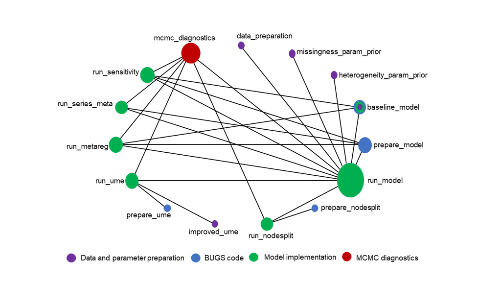

Figure 1: Network of functions for data preparation and model implementation